# An introduction to `R` for ecological modeling (lab 1)

Stephen Ellner, modified by Ben Bolker & Bob Douma. Adapted to R Markdown by Alejandro Morales. Morales

October 8, 2018

# 1 Learning outcomes

The aim of this tutorial is to learn the basics of `R`. After completing the tutorial you will be able to:

1. Install `R` and associated packages and Rstudio
2. Do interactive calculations in the `R` console
3. Consult the built-in help in `R`
4. Create, modify and run `R` scripts
5. Setup a typical workflow in `R` (loading libraries, reading data, doing statistics and saving results)
6. Work with the most common data types in `R` (vectors, matrices, lists and data frames)

# 2 How to use this tutorial

- This tutorial contains many sample calculations. It is important to do these yourself—**type them in at your keyboard and see what happens on your screen**—to get the feel of working in `R`.
- **Exercises** in the middle of a section should be done immediately, and make sure you have them rightly solved before moving on. Some more challenging exercises (indicated by asterisks) appear at the end of some sections. These can be left until later, and may be assigned as homework.

# 3 What is `R`?

`R` is an object-oriented scripting language that combines

- a programming language called S-lang, developed by John Chambers at Bell Labs, that can be used for numerical simulation of deterministic and stochastic dynamic models.
- an extensive set of functions for classical and modern statistical data analysis and modeling.
- graphics functions for visualizing data and model output
- a user interface with a few basic menus and extensive help facilities

`R` is an open source project, available for free download via the Web. Originally a research project in statistical computing (Ihaka and Gentleman, 1996), it is now managed by a development team that includes a number of well-regarded statisticians, and is widely used by statistical researchers (and a growing number of theoretical ecologists and ecological modelers) as a platform for making new methods available to users. The commercial implementation of Slang (called S-PLUS) offers an Office-style “point and click”" interface that `R` lacks. For our purposes, however, the advantage of this front-end is outweighed by the fact that `R` is built on a faster and much less memory-hungry implementation of Slang and is easier to use in combination with other languages (and is free!).

A standard installation of `R` also includes extensive documentation, including an introductory manual ($\approx 100$ pages) and a comprehensive reference manual (over 1000 pages). (There is a graphical front-end for parts of `R`, called “`R` commander” (Rcmdr for short), available at the `R` site, but we will not be using it in this class.)

# 4 Installing `R` on your computer: basics

If `R` is already installed on your computer, you can skip this section.

The main source for `R` is the CRAN home page `http://cran.r-project.org`. You can get the source code, but most users will prefer a precompiled version. To get one of these from CRAN:

- go to `http://cran.r-project.org/mirrors.html` and find a mirror site that is geographically somewhat near you.
- Find the appropriate page for your operating system — when you get to the download section, go to `base` rather than `contrib`. Download the binary file (e.g. `base/R-x.y.z-win32.exe` for Windows, `R-x.y.z.dmg` for MacOS, where `x.y.z` is the version number). The binary files are large (30–60 megabytes) — you will need to find a fast internet connection.
- Read and follow the instructions (which are pretty much “click on the icon”).

The standard distributions of `R` include several *packages*, user-contributed suites of add-on functions (unfortunately, the command to load a package into `R` is `library`!). These Notes use some packages that are not part of the standard distribution. In general, you can install additional packages from within `R` using the `Packages` menu, or the `install.packages` command. (See below.)

# 5 Installing and using Rstudio

Nowadays programs are available that integrate `R` in a sophisticated way by combining a console, a *syntax highlighting* editor (giving colors to `R` commands and allowing you to identify missing parentheses, quotation marks etc.), tools for plotting, debugging, workspace management and connections to versioning systems into one program. Rstudio is currently the most advanced wrapper around R and is highly recommended if `R` is the core of your work. Rstudio can be found and downloaded at https://www.rstudio.com.

If a new `R` version is launched after you installed Rstudio, you can change the `R` version that is used in Rstudio by clicking on `Tools` and `Global Options`, choose `R general` and select the location of the most recent `R` version.

Rstudio usually displays four panels. The default setting is a script editor at the top-left of the screen, the console at the bottom-left, the global environment (which shows what is stored in the memory) at the top-right, and a plotting region at bottom-right. As you see some panel have multiple tabs that include other useful features such as the help (bottom-right), the (available and loaded) packages (bottom-right) etc.

# 6 The `R` package system

`R` has many extra packages that provide extra functions. You may be able to install new packages from a menu within `R`. You can always type

```r
install.packages("ggplot2")
```

(for example — this installs the `ggplot2` package). You can install more than one package at a time:

```r
install.packages(c("ggplot2","nlme"))
```

(`c` stands for “combine”, and is the command for combining multiple things into a single object.)

# 7 Interactive calculations in the console

The console is where you enter commands for `R` to execute *interactively*, meaning that the command is executed and the result is displayed as soon as you hit the `Enter` key (bottom-left panel in Rstudio). For example, at the command prompt `>`, type in `2+2` and hit `Enter`; you will see

```r
2+2
```

```
## [1] 4
```

To do anything complicated, you have to store the results from calculations by *assigning* them to variables, using `=` or `<-`. For example:

```r
a=2+2
```

`R` automatically creates the variable `a` and stores the result (4) in it, but it doesn’t print anything. This may seem strange, but you’ll often be creating and manipulating huge sets of data that would fill many screens, so the default is to skip printing the results. To ask `R` to print the value, just type the variable name by itself at the command prompt:

```r
a
```

```
## [1] 4
```

(the `[1]` at the beginning of the line is just `R` printing an index of element numbers; if you print a result that displays on multiple lines, `R` will put an index at the beginning of each line. `print(a)` also works to print the value of a variable.) By default, a variable created this way is a *vector*, and it is *numeric* because we gave `R` a number rather than some other type of data (e.g. a character string like `"pxqr"`). In this case `a` is a numeric vector of length 1, which acts just like a number.

You could also type `a=2+2; a`, using a semicolon to put two or more commands on a single line. Conversely, you can break lines *anywhere that `R` can tell you haven’t finished your command* and `R` will give you a “continuation” prompt (`+`) to let you know that it doesn’t think you’re finished yet: try typing

```r
a=3*(4+ [Enter]
5)
```

to see what happens (you will sometimes see the continuation prompt when you don’t expect it, e.g. if you forget to close parentheses).If you get stuck continuing a command you don’t want—e.g. you opened the wrong parentheses—just hit the `Escape` key or the stop icon in the menu bar to get out.

Variable names in `R` must begin with a letter, followed by letters or numbers. You can break up long names with a period, as in `very.long.variable.number.3`, or an underscore (`_`), but you can’t use blank spaces in variable names (or at least it’s not worth the trouble). Variable names in `R` are case sensitive, so `Abc` and `abc` are different variables. Make variable names long enough to remember, short enough to type.`N.per.ha` or `pop.density` are better than `x` and `y` (too short) or `available.nitrogen.per.hectare` (too long). Avoid `c`, `l`, `q`, `t`, `C`, `D`, `F`, `I`, and `T`, which are either built-in `R` functions or hard to tell apart.

`R` does calculations with variables as if they were numbers. It uses `+`, `-`, `*`, `/`, and `^` for addition, subtraction, multiplication, division and exponentiation, respectively. For example:

```r
x=5
y=2
z1=x*y ## no output
z2=x/y ## no output
z3=x^y ## no output
z2
```

```
## [1] 2.5
```

```r
z3
```

```
## [1] 25
```

Even though `R` did not display the values of `x` and `y`, it “remembers” that it assigned values to them. Type `x; y` to display the values.

You can retrieve and edit previous commands. The up-arrow ($\uparrow$) in the console recalls previous commands to the prompt. They also can be found in the top-right tab `History`. For example, you can bring back the second-to-last command and edit it into

```r
z3=2*x^y
```

You can combine several operations in one calculation:

```r
A=3
C=(A+2*sqrt(A))/(A+5*sqrt(A))
C
```

```
## [1] 0.5543706
```

Parentheses specify the order of operations. The command

```r
C=A+2*sqrt(A)/A+5*sqrt(A)
```

is not the same as the one above; rather, it is equivalent to `C=A + 2*(sqrt(A)/A) + 5*sqrt(A)`.

The default order of operations is: (1) parentheses; (2) exponentiation, or powers, (3) multiplication and division, (4) addition and subtraction.

b = 12-4/2^3 gives 12 - 4/8 = 12 - 0.5 = 11.5

b = (12-4)/2^3 gives 8/8 = 1

b = -1^2 gives -(1^2) = -1

b = (-1)^2 gives 1

**Exercise 7.1**: Using editing shortcuts wherever you can, have `R` compute the values of

1. $\frac{2^7}{2^7 - 1}$ and compare it with $( {1 - \frac{1}{2^7}} )^{-1}$ (If any square brackets [] show up in your web browser’s rendition of these equations, replace them with regular parentheses ().)
- $1+0.2$
- $1+0.2+0.2^2/2$
- $1+0.2+0.2^2/2+0.2^3/6$
- $e^{0.2}$ (remember that `R` knows `exp` but not $e$; how would you get `R` to tell you the value of $e$? What is the point of this exercise?)
3. the standard normal probability density, $\frac{1}{\sqrt{2 \pi}} e^{-x^2/2}$, for values of $x=1$ and $x=2$ (`R` knows $\pi$ as `pi`.) (You can check your answers against the built-in function for the normal distribution; `dnorm(1)` and `dnorm(2)` should give you the values for the standard normal for $x=1$ and $x=2$.)

# 8 The help system

R has a help system, although it is generally better for providing detail or reminding you how to do things than for basic ``how do I …?’’ questions.

- You can get help on any R function by entering

  ```
  ?foo
  ```

  (where `foo` is the name of the function you are interested in) in the console window (e.g., try `?sin`).
- `??topic` or `help.search("topic")` (with quotes) will list information related to `topic` available in the base system or in any extra installed packages: then use `?topic` to see the information, perhaps using `library(pkg)` to load the appropriate package first. `help.search` uses “fuzzy matching” — for example, `help.search("log")` finds 528 entries (on my particular system) including lots of functions with “plot”, which includes the letters “lot”, which are *almost* like “log”. If you can’t stand it, you can turn this behavior off by specifying the incantation `help.search("log",agrep=FALSE)` (81 results which still include matches for “logistic”, “myelogenous”, and “phylogeny” …)

**Other (on-line) help resources - just google it** In our experience, the help provided by `R` requires some experience in the `R` language to be able to understand it. Therefore, a general, but practical advice is to google your problem. In 99.9% of the cases someone else had a similar question in the past which were solved by the `R` community. Place were you likely will find answers are https://stackoverflow.com or https://stat.ethz.ch.

**Exercise 8.1**: Do an Apropos on `sin` via the Help menu, to see what it does. Now enter the command

```r
help.search("sin")
```

and see what that does (answer: `help.search` pulls up all help pages that include ‘sin’ anywhere in their title or text. Apropos just looks at the name of the function).

# 9 Using scripts and data files

Modeling and complicated data analysis are often much easier if you use *scripts*, which are a series of commands stored in a text file. Scripting has a number of advantages and should be standard practice when doing statstics for reasons of transparency (you can see what you have done), repeatability (tomorrow you will get the same result as today) and transferability (a colleague can easily check what you have done and redo your analysis). Even for relatively simple tasks, script files are useful for building up a calculation step-by-step, making sure that each part works before adding on to it. We recommend you making a habit typing all commands in a script editor before sending it the console, otherwise important parts of your analysis may get lost because you did not store them.

Rstudio has an advanced script editor that recognizes `R` syntax by giving different colors to different `R` commands and by automatic completion of parentheses. You can also use Windows Notepad or Wordpad but you **should not** use MS Word.

Most programs for working with models or analyzing data follow a simple pattern of program parts:

1. “Setup” statements.
- For example, load some packages, or run another script file that creates some functions (more on functions later).
2. Input some data from a file or the keyboard.
- Read in data from a text file.
3. Carry out the calculations that you want.
- Fit several statistical models to the data and compare them.
4. Print the results, graph them, or save them to a file.
- Graph the results, and save the graph to disk for including in your term project.

Tips for working with data and script files (sounding slightly scary but just trying to help you avoid common pitfalls):

- To tell `R` where data and script files are located, you can do any one of the following:
- spell out the *path*, or file location, explicitly. (Use a single forward slash to separate folders (e.g. `"c:/My Documents/R/script.R"`): this works on all platforms.)
- change your working directory to wherever the file(s) are located using the `setwd` (**set** **w**orking **d**irectory) function, e.g. `setwd("c:/temp")` or through clicking on ‘Session’ and ‘set working directory’. Changing your working directory is more efficient in the long run, if you save all the script and data files for a particular project in the same directory and switch to that directory when you start work.

# 10 Typical workflow in `R`: an example using linear regression

To get a feel for a typical workflow in R we’ll fit a straight-line model (linear regression) to data.

Start a blank `R` script (File -> New File -> R script) and save it on a convenient location.

Below are some data on the maximum growth rate $r_{max}$ of laboratory populations of the green alga *Chlorella vulgaris* as a function of light intensity ($\mu$E per m$^2$ per second). These experiments were run during the system-design phase of the study reported by Fussman et al. (2000).

Light: 20, 20, 20, 20, 21, 24, 44, 60, 90, 94, 101

$r_{max}$: 1.73, 1.65, 2.02, 1.89, 2.61, 1.36, 2.37, 2.08, 2.69, 2.32, 3.67

To analyze these data in R, first enter them as numerical *vectors* in your script and send them to the console:

```r
Light=c(20,20,20,20,21,24,44,60,90,94,101)
rmax=c(1.73,1.65,2.02,1.89,2.61,1.36,2.37,2.08,2.69,2.32,3.67)
```

The function `c` *combines* the individual numbers into a vector. Try recalling (with $\uparrow$) and modifying the above command to

```
Light=20,20,20,20,21,24,44,60,90,94,101
```

and see the error message you get: in order to create a vector of specified numbers, you **must** use the `c` function. Don’t be afraid of error messages: the answer to “what would happen if I …?” is usually “try it and see!”

To see a histogram of the growth rates enter `hist(rmax)`, which opens a graphics window and displays the histogram. There are *many* other built-in statistics functions: for example `mean(rmax)` computes you the mean, and `sd(rmax)` and `var(rmax)` compute the standard deviation and variance, respectively. Play around with these functions, and any others you can think of.

To see how light intensity affects algal rate of increase, type

```r
plot(rmax ~ Light)
```

in the script (and send it the console) to plot `rmax` ($y$) against `Light` ($x$). The `~` sign implies “as a function of”. Alternatively, type `plot(Light,rmax)`. A linear regression would seem like a reasonable model for these data. **Don’t close this plot window**: we’ll soon be adding to it.

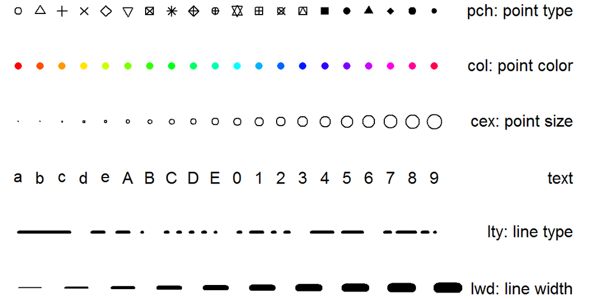

Some of R’s graphics parameters. Color specification, `col`, also applies in many other contexts: colors are set to a rainbow scale here. See `?par` for (many more) details on graphics parameters, and one or more of `?rgb`, `?palette`, or `apropos("color")` for more on colors.

`R`’s default plotting character is an open circle. Open symbols are generally better than closed symbols for plotting because it is easier to see where they overlap, but you could include `pch=16` in the `plot` command if you wanted closed circles instead. Figure 1 shows several more ways to adjust the appearance of lines and points in `R`.

To perform linear regression we create a linear model using the `lm` (**l**inear **m**odel) function:

```r
fit = lm(rmax~Light)
```

(Note that linear model is read as “model $r_{max}$ as a function of light”.)

The `lm` command produces no output at all, but it creates `fit` as an **object**, i.e. a data structure consisting of multiple parts, holding the results of a regression analysis with `rmax` being modeled as a function of `Light`. Unlike most statistics packages, R rarely produces automatic summary output from an analysis. Statistical analyses in R are done by creating a model, and then giving additional commands to extract desired information about the model or display results graphically.

To get a summary of the results, enter the command `summary(fit)`. `R` sets up model objects (more on this later) so that the function `summary` “knows” that `fit` was created by `lm`, and produces an appropriate summary of results for an `lm` object:

```r
summary(fit)
```

```
##
## Call:
## lm(formula = rmax ~ Light)
##
## Residuals:
##     Min      1Q  Median      3Q     Max
## -0.5478 -0.2607 -0.1166  0.1783  0.7431
##
## Coefficients:
##             Estimate Std. Error t value Pr(>|t|)
## (Intercept) 1.580952   0.244519   6.466 0.000116 ***
## Light       0.013618   0.004317   3.154 0.011654 *
## ---
## Signif. codes:  0 '***' 0.001 '**' 0.01 '*' 0.05 '.' 0.1 ' ' 1
##
## Residual standard error: 0.4583 on 9 degrees of freedom
## Multiple R-squared:  0.5251, Adjusted R-squared:  0.4723
## F-statistic: 9.951 on 1 and 9 DF,  p-value: 0.01165
```

You can add the regression line to the plot of the data with a function taking `fit` as its input (if you closed the plot of the data, you will need to create it again in order to add the regression line):

```r
abline(fit)
```

(`abline`, pronounced “a b line”, is a general-purpose function for adding lines to a plot: you can specify horizontal or vertical lines, a slope and an intercept, or a regression model: `?abline`).

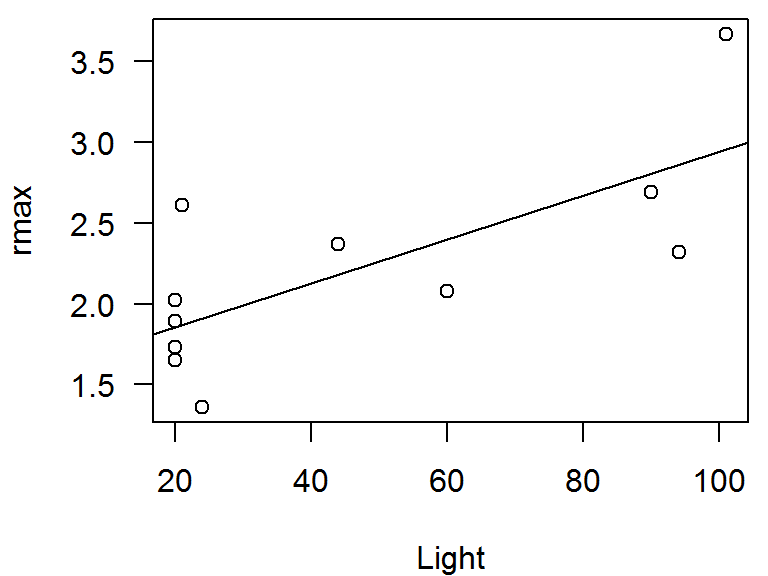

Graphical summary of regression analysis

You can get the coefficients by using the `coef` function:

```r
coef(fit)
```

```
## (Intercept)       Light
##  1.58095214  0.01361776
```

You can also “interrogate” `fit` directly. Type `names(fit)` to get a list of the components of `fit`, and then use the `$` symbol to extract components according to their names.

```r
names(fit)
```

```
##  [1] "coefficients"  "residuals"     "effects"       "rank"
##  [5] "fitted.values" "assign"        "qr"            "df.residual"
##  [9] "xlevels"       "call"          "terms"         "model"
```

For more information (perhaps more than you want) about `fit`, use `str(fit)` (for **str**ucture). You can get the regression coefficients this way:

```r
fit$coefficients
```

```
## (Intercept)       Light
##  1.58095214  0.01361776
```

It’s good to be able to look inside `R` objects when necessary, but all other things being equal you should prefer (e.g.) `coef(x)` to `x$coefficients`.

Usually data is loaded from a file. To illustrate this, grab copies of `Intro2.R` and `ChlorellaGrowth.txt` from the web page (blackboard) to see how this is done. In `ChlorellaGrowth.txt` the two variables are entered as columns of a data matrix. Then instead of typing these in by hand, the command

```r
X=read.table("ChlorellaGrowth.txt",header=TRUE)
```

reads the file (**from the current directory**) and puts the data values into the variable `X`; `header=TRUE` specifies that the file includes column names. **Note** that as specified above you need to make sure that `R` is looking for the data file in the right place … either move the data file to your current working directory, or change the line so that it points to the actual location of the data file.

Extract the variables from `X` with the commands

```r
Light=X[,1]
rmax=X[,2]
```

Think of these as shorthand for “`Light` = everything in column 1 of `X`”, and “`rmax` = everything in column 2 of `X`” (we’ll learn about working with data matrices later). From there on out it’s the same as before, with some additions that set the axis labels and add a title.

**Exercise 10.1** Make a copy of `Intro2.R` under a new name, and modify the copy so that it does linear regression of algal growth rate on the natural log of light intensity, `LogLight=log(Light)`, and plots the data appropriately. You should end up with a graph that resembles Figure 3. (*Hint:* when you switch from light intensity to log light intensity, the range on your $x$ axis will change and you will have to change the $x$ position at which you plot the growth rate equation.)

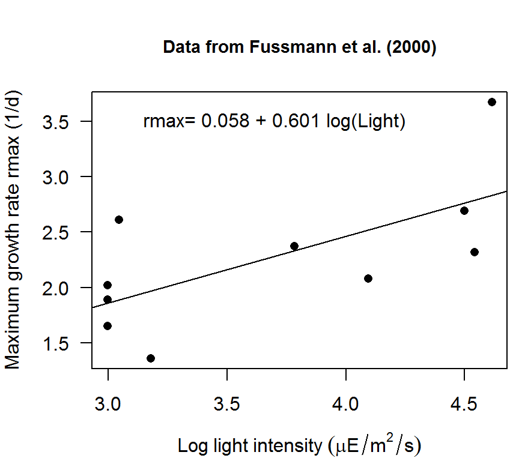

Graphical summary of regression analysis, using log of light intensity (and annotating the plot)

**Exercise 10.2** Run `Intro2.R`, then enter the command `plot(fit)` in the console and follow the directions in the console. Figure out what just happened by entering `?plot.lm` to bring up the Help page for the function `plot.lm` that carries out a `plot` command for an object produced by `lm`. (This is one example of how R uses the fact that statistical analyses are stored as model objects. `fit` “knows” what kind of object it is (in this case an object of type `lm`), and so `plot(fit)` invokes a function that produces plots suitable for an `lm` object.) **Answer:** R produced a series of diagnostic plots exploring whether or not the fitted linear model is a suitable fit to the data. In each of the plots, the 3 most extreme points (the most likely candidates for “outliers”) have been identified according to their sequence in the data set.

**Exercise 10.3** The axes in plots are scaled automatically, but the outcome is not always ideal (e.g. if you want several graphs with exactly the same axis limits). You can use the `xlim` and `ylim` arguments in `plot` to control the limits:

```
plot(x,y,xlim=c(x1,x2), [other stuff])
```

will draw the graph with the $x$-axis running from `x1` to `x2`, and using `ylim=c(y1,y2)` within the `plot` command will do the same for the $y$-axis.

Create a plot of growth rate versus light intensity with the $x$-axis running from 0 to 120 and the $y$-axis running from 1 to 4.

**Exercise 10.4** You can place several graphs within a single figure by using the `par` function (short for “parameter”) to adjust the layout of the plot. For example, the command

```r
par(mfrow=c(2,3))
```

divides the plotting area into 2 rows and 3 columns. As `R` draws a series of graphs, it places them along the top row from left to right, then along the next row, and so on. `mfcol=c(2,3)` has the same effect except that `R` draws successive graphs down the first column, then down the second column, and so on.

Modify the script as follows. Use `mfcol=c(2,1)` to create graphs of growth rate as a function of `Light`, and of `log(growth rate)` as a function of `log(Light)` in the same figure. Do the same again, using `mfcol=c(1,2)`.

**Exercise 10.5 *** Use `?par` to read about other plot control parameters that you use `par` to set (you should definitely skim — this is one of the longest help files in the whole R system!). Then draw a $2 \times 2$ set of plots, each showing the line $y=5x+3$ with $x$ running from 3 to 8, but with 4 different line styles and 4 different line colors.

**Exercise 10.6 *** Modify one of your scripts so that at the very end it saves the plot to disk. In Windows you can do this with `savePlot`, otherwise with `dev.print`. Use `?savePlot`, `?dev.print` to read about these functions. Note that the argument `filename` can include the path to a folder; for example, in Windows you can use `filename="c:/temp/Intro2Figure".`

(These are really exercises in using the help system, with the bonus that you learn some things about `plot`. (Let’s see, we know `plot` can graph data points ($r_{max}$ versus $Light$ and all that). Maybe it can also draw a line to connect the points, or just draw the line and leave out the points. That would be useful. So let’s try `?plot` and see if it says anything about lines … Hey, it also says that `graphical parameters can be given as arguments to plot`, so maybe I can set line colors inside the plot command instead of using `par` all the time …). The help system can be quite helpful (amazingly enough) once you get used to it and get in the habit of using it often.)

The main point is not to be afraid of experimenting; if you have saved your previous commands in a script file, there’s almost nothing you can break by trying out commands and inspecting the results.

# 11 Data types

`R` distinguishes a number of data types including vectors, matrices, data frames and lists that each have special properties and which are used for calculations and data storage.

## 11.1 Vectors

An important class of data types are vectors and matrices (1- and 2-dimensional rectangular arrays of numbers). Operations with vectors and matrices may seem a bit abstract now, but we need them to do useful things later. The only properties of vectors are their type (or *class*) and length, although they can also have an associated list of names.

We’ve already seen two ways to create vectors in `R`:

1. A command in the console window or a script file listing the values, such as

```r
initialsize=c(1,3,5,7,9,11)
```

2. Using `read.table`:

```r
initialsize=read.table("c:/temp/initialdata.txt")
```

(assuming of course that the file exists in the right place).

You can then use a vector in calculations as if it were a number (more or less)

```r
finalsize=initialsize+1
newsize=sqrt(initialsize)
finalsize
```

```
## [1]  2  4  6  8 10 12
```

Notice that `R` applied each operation to every entry in the vector. Similarly, commands like `initialsize-5, 2*initialsize, initialsize/10` apply subtraction, multiplication, and division to each element of the vector. The same is true for

```r
initialsize^2
```

```
## [1]   1   9  25  49  81 121
```

In `R` the default is to apply functions and operations to vectors in an *element by element* (or “vectorized”) manner. This is an extremely useful propery in `R`

### 11.1.1 Functions for creating vectors

You can use the `seq` function to create a set of regularly spaced values. `seq`’s syntax is `x=seq(from,to,by)` or `x=seq(from,to)` or `x=seq(from,to,length.out)`. The first form generates a vector `(from,from+by,from+2*by,...)` with the last entry not extending further than than `to`. In the second form the value of `by` is assumed to be 1 or -1, depending on whether `from` or `to` is larger. The third form creates a vector with the desired endpoints and length. The syntax `from:to` is a shortcut for `seq(from,to)`:

```r
1:8
```

```
## [1] 1 2 3 4 5 6 7 8
```

**Exercise 11.1** Use `seq` to create the vector `v=(1 5 9 13)`, and to create a vector going from 1 to 5 in increments of 0.2.

You can use `rep` to create a constant vector such as `(1 1 1 1)`; the basic syntax is `rep(values,lengths)`. For example,

```r
rep(3,5)
```

```
## [1] 3 3 3 3 3
```

creates a vector in which the value 3 is repeated 5 times. `rep` will repeat a whole vector multiple times

```r
rep(1:3,3)
```

```
## [1] 1 2 3 1 2 3 1 2 3
```

or will repeat each of the elements in a vector a given number of times:

```r
rep(1:3,each=3)
```

```
## [1] 1 1 1 2 2 2 3 3 3
```

Even more flexibly, you can repeat each element in the vector a different number of times:

```r
rep( c(3,4),c(2,5) )
```

```
## [1] 3 3 4 4 4 4 4
```

The value 3 was repeated 2 times, followed by the value 4 repeated 5 times. `rep` can be a little bit mind-blowing as you get started, but it will turn out to be useful.

### 11.1.2 Vector indexing

You will often want to extract a specific entry or other part of a vector. This procedure is called *vector indexing*, and uses square brackets (`[]`):

```r
z=c(1,3,5,7,9,11)
z[3]
```

```
## [1] 5
```

(how would you use `seq` to construct `z`?) `z[3]` extracts the third item, or *element*, in the vector `z`. You can also access a block of elements using the functions for vector construction, e.g.

```r
z[2:5]
```

```
## [1] 3 5 7 9
```

extracts the second through fifth elements.

What happens if you enter `v=z[seq(1,5,2)]` ? Try it and see, and make sure you understand what happened.

You can extracted irregularly spaced elements of a vector. For example

```r
z[c(1,2,5)]
```

```
## [1] 1 3 9
```

You can also use indexing to **set specific values within a vector**. For example,

```r
z[1]=12
```

changes the value of the first entry in `z` while leaving all the rest alone, and

```r
z[c(1,3,5)]=c(22,33,44)
```

changes the first, third, and fifth values (note that we had to use `c` to create the vector — can you interpret the error message you get if you try `z[1,3,5]` ?)

**Exercise 11.2** Write a *one-line* command to extract a vector consisting of the second, first, and third elements of `z` *in that order*.

**Exercise 11.3** Write a script file that computes values of $y=\frac{(x-1)}{(x+1)}$ for $x=1,2,\cdots,10$, and plots $y$ versus $x$ with the points plotted and connected by a line (hint: in `?plot`, search for `type`).

**Exercise 11.4*** The sum of the geometric series $1 + r + r^2 + r^3 + ... + r^n$ approaches the limit $1/(1-r)$ for $r < 1$ as $n \rightarrow \infty$. Set the values $r=0.5$ and $n=10$, and then write a **one-line** command that creates the vector $G = (r^0,r^1,r^2,...,r^n)$. Compare the sum (using `sum`) of this vector to the limiting value $1/(1-r)$. Repeat for $n=50$. (*Note* that comparing very similar numeric values can be tricky: rounding can happen, and some numbers cannot be represented exactly in binary (computer) notation. By default `R` displays 7~significant digits (`options("digits")`).

For example:

```r
x = 1.999999
x
```

```
## [1] 1.999999
```

```r
x-2
```

```
## [1] -1e-06
```

```r
x=1.9999999999999
x
```

```
## [1] 2
```

```r
x-2
```

```
## [1] -9.992007e-14
```

All the digits are still there, in the second case, but they are not shown. Also note that `x-2` is not exactly $-1 \times 10^{-13}$; this is unavoidable.)

### 11.1.3 Logical operators

Logical operators return a value of `TRUE` or `FALSE`. For example, try:

```r
a=1
b=3
c=a<b
d=(a>b)
c
```

```
## [1] TRUE
```

```r
d
```

```
## [1] FALSE
```

The parentheses around (`a>b`) are optional but make the code easier to read. One special case where you *do* need parentheses (or spaces) is when you make comparisons with negative values; `a<-1` will surprise you by setting `a=1`, because `<-` (representing a left-pointing arrow) is equivalent to `=` in `R`. Use `a< -1`, or more safely `a<(-1)`, to make this comparison.

When we compare two vectors or matrices of the same size, or compare a number with a vector or matrix, comparisons are done element-by-element. For example,

```r
x=1:5
(b=(x<=3))
```

```
## [1]  TRUE  TRUE  TRUE FALSE FALSE
```

So if `x` and `y` are vectors, then `(x==y)` will return a vector of values giving the element-by-element comparisons. If you want to know whether `x` and `y` are identical vectors, use `identical(x,y)` which returns a single value: `TRUE` if each entry in `x` equals the corresponding entry in `y`, otherwise `FALSE`. You can use `?Logical` to read more about logical operators. **Note the difference between = and ==: can you figure out what happened in the following cautionary tale?**

```r
a = 1:3
b = 2:4
a==b
```

```
## [1] FALSE FALSE FALSE
```

```r
a=b
a==b
```

```
## [1] TRUE TRUE TRUE
```

Exclamation points `!` are used in `R` to mean “not”; `!=` (not `==`) means “not equal to”.

OR is *non-exclusive*, meaning that `x|y` is true if either `x` or `y` *or both* are true (a ham-and-cheese sandwich would satisfy the condition “ham OR cheese”). For example, try

```r
a=c(1,2,3,4)
b=c(1,1,5,5)
(a<b)& (a>3)
```

```
## [1] FALSE FALSE FALSE  TRUE
```

```r
(a<b) | (a>3)
```

```
## [1] FALSE FALSE  TRUE  TRUE
```

and make sure you understand what happened (if it’s confusing, try breaking up the expression and looking at the results of `a<b` and `a>3` separately first). The two forms of AND and OR differ in how they handle vectors. The shorter one does element-by-element comparisons; the longer one only looks at the first element in each vector.

We can also use *logical* vectors (lists of `TRUE` and `FALSE` values) to pick elements out of vectors. This is important, e.g., for subsetting data (getting rid of those pesky outliers!)

As a simple example, we might want to focus on just the low-light values of $r_{max}$ in the *Chlorella* example:

```r
X=read.table("ChlorellaGrowth.txt",header=TRUE)
Light=X[,1]
rmax=X[,2]
lowLight = Light[Light<50]
lowLightrmax = rmax[Light<50]
lowLight
```

```
## [1] 20 20 20 21 24 44
```

```r
lowLightrmax
```

```
## [1] 1.65 2.02 1.89 2.61 1.36 2.37
```

What is really happening here (think about it for a minute) is that `Light<50` generates a logical vector the same length as `Light` (`TRUE TRUE TRUE ...`) which is then used to select the appropriate values.

If you want the positions at which `Light` is lower than 50, you could say `(1:length(Light))[Light<50]`, but you can also use a built-in function: `which(Light<50)`. If you wanted the position at which the maximum value of `Light` occurs, you could say `which(Light==max(Light))`. (This normally results in a vector of length 1; when could it give a longer vector?) There is even a built-in command for this specific function, `which.max` (although `which.max` always returns just the *first* position at which the maximum occurs).

**Exercise 11.5**: What would happen if instead of setting `lowLight` you replaced `Light` by saying `Light=Light[Light<50]`, and then `rmax=rmax[Light<50]`? Why would that be wrong? Try it with some temporary variables — set `Light2=Light` and `rmax2=rmax` and then play with `Light2` and `rmax2` so you don’t mess up your working variables — and work out what happened …

We can also combine logical operators (making sure to use the element-by-element `&` and `|` versions of AND and OR):

```r
Light[Light<50 & rmax <= 2.0]
```

```
## [1] 20 20 24
```

```r
rmax[Light<50 & rmax <= 2.0]
```

```
## [1] 1.65 1.89 1.36
```

**Exercise 11.6** `runif(n)` is a function (more on it soon) that generates a vector of `n` random, uniformly distributed numbers between 0 and 1. Create a vector of 20 numbers, then select the subset of those numbers that is less than the mean. (If you want your answers to match mine exactly, use `set.seed(273)` to set the random-number generator to a particular starting point before you use `runif`; [273 is an arbitrary number I chose].)

**Exercise 11.7*** Find the *positions* of the elements that are less than the mean of the vector you just created (e.g. if your vector were `(0.1 0.9. 0.7 0.3)` the answer would be `(1 4)`).

As I mentioned in passing above, vectors can have names associated with their elements: if they do, you can also extract elements by name (use `names` to find out the names).

```r
x = c(first=7,second=5,third=2)
names(x)
```

```
## [1] "first"  "second" "third"
```

```r
x["first"]
```

```
## first
##     7
```

```r
x[c("third","first")]
```

```
## third first
##     2     7
```

Finally, it is sometimes handy to be able to drop a particular set of elements, rather than taking a particular set: you can do this with negative indices. For example, `x[-1]` extracts all but the first element of a vector.

**Exercise 11.8*** : Specify two ways to take only the elements in the odd positions (first, third, …) of a vector of arbitrary length.

## 11.2 Matrices

### 11.2.1 Creating matrices

Like vectors, you can create matrices by using `read.table` to read in values from a data file. (Actually, this creates a data frame, which is *almost* the same as a matrix — see next section). You can also create matrices of numbers by creating a vector of the matrix entries, and then reshaping them to the desired number of rows and columns using the function `matrix`. For example

```r
(X=matrix(1:6,nrow=2,ncol=3))
```

```
##      [,1] [,2] [,3]
## [1,]    1    3    5
## [2,]    2    4    6
```

takes the values 1 to 6 and reshapes them into a 2 by 3 matrix.

By default `R` loads the values into the matrix *column-wise* (this is probably counter-intuitive since we’re used to reading tables row-wise). Use the optional parameter `byrow` to change this behavior. For example :

```r
(A=matrix(1:9,nrow=3,ncol=3,byrow=TRUE))
```

```
##      [,1] [,2] [,3]
## [1,]    1    2    3
## [2,]    4    5    6
## [3,]    7    8    9
```

`R` will re-cycle through entries in the data vector, if necessary to fill a matrix of the specified size. So for example

```r
matrix(1,nrow=10,ncol=10)
```

creates a $10 \times 10$ matrix of ones.

**Exercise 11.1** Use a command of the form `X=matrix(v,nrow=2,ncol=4)` where `v` is a data vector, to create the following matrix `X`:

```
##      [,1] [,2] [,3] [,4]
## [1,]    1    1    1    1
## [2,]    2    2    2    2
```

If you can, try to use `R` commands to construct the vector rather than typing out all of the individual values.

`R` will also collapse a matrix to behave like a vector whenever it makes sense: for example `sum(X)` above is 12.

**Exercise 11.2** Use `rnorm` (which is like `runif`, but generates Gaussian (normally distributed) numbers with a specified mean and standard deviation instead) and `matrix` to create a $5 \times 7$ matrix of Gaussian random numbers with mean 1 and standard deviation 2. (Use `set.seed(273)` again for consistency.)

Another useful function for creating matrices is `diag`. `diag(v,n)` creates an $n \times n$ matrix with data vector $v$ on its diagonal. So for example `diag(1,5)` creates the $5 \times 5$ *identity matrix*, which has 1’s on the diagonal and 0 everywhere else. Try `diag(1:5,5)` and `diag(1:2,5)`; why does the latter produce a warning?

Finally, you can use the `data.entry` function. This function can only edit existing matrices, but for example (try this now!!)

```r
A=matrix(0,nrow=3,ncol=4)
data.entry(A)
```

will create `A` as a $3 \times 4$ matrix, and then call up a spreadsheet-like interface in which you can change the values to whatever you need.

### 11.2.2 `cbind` and `rbind`

If their sizes match, you can combine vectors to form matrices, and stick matrices together with vectors or other matrices. `cbind` (“column bind”) and `rbind` (“row bind”) are the functions to use.

`cbind` binds together columns of two objects. One thing it can do is put vectors together to form a matrix:

```r
(C=cbind(1:3,4:6,5:7))
```

```
##      [,1] [,2] [,3]
## [1,]    1    4    5
## [2,]    2    5    6
## [3,]    3    6    7
```

`R` interprets vectors as row or column vectors according to what you’re doing with them. Here it treats them as column vectors so that columns exist to be bound together. On the other hand,

```r
(D=rbind(1:3,4:6))
```

```
##      [,1] [,2] [,3]
## [1,]    1    2    3
## [2,]    4    5    6
```

treats them as rows. Now we have two matrices that can be combined.

**Exercise 11.3** Verify that `rbind(C,D)` works, `cbind(C,C)` works, but `cbind(C,D)` doesn’t. Why not?

### 11.2.3 Matrix indexing

Matrix indexing is like vector indexing except that you have to specify both the row and column, or range of rows and columns. For example `z=A[2,3]` sets `z` equal to 6, which is the (2nd row, 3rd column) entry of the matrix **A** that you recently created, and

```r
A[2,2:3]
```

```
## [1] 5 6
```

```r
(B=A[2:3,1:2])
```

```
##      [,1] [,2]
## [1,]    4    5
## [2,]    7    8
```

There is an easy shortcut to extract entire rows or columns: leave out the limits, leaving a blank before or after the comma.

```r
(first.row=A[1,])
```

```
## [1] 1 2 3
```

```r
(second.column=A[,2])
```

```
## [1] 2 5 8
```

(What does `A[,]` do?)

As with vectors, indexing also works in reverse for assigning values to matrix entries. For example,

```r
(A[1,1]=12)
```

```
## [1] 12
```

You can do the same with blocks, rows, or columns, for example

```r
(A[1,]=c(2,4,5))
```

```
## [1] 2 4 5
```

If you use `which` on a matrix, `R` will normally treat the matrix as a vector — so for example `which(A==8)` will give the answer 6 (figure out why). However, `which` does have an option that will treat its argument as a matrix:

```r
which(A==8,arr.ind=TRUE)
```

```
##      row col
## [1,]   3   2
```

## 11.3 Lists

While vectors and matrices may seem familiar, lists are probably new to you. Vectors and matrices have to contain elements that are all the same type: lists in `R` can contain anything — vectors, matrices, other lists … Indexing lists is a little different too: use double square brackets `[[ ]]` (rather than single square brackets as for a vector) to extract an element of a list by number or name, or `$` to extract an element by name (only). Given a list like this:

```r
L = list(A=x,B=y,C=c("a","b","c"))
```

Then `L$A`, `L[["A"]]`, and `L[[1]]` will all grab the first element of the list.

You won’t use lists too much at the beginning, but many of `R`’s own results are structured in the form of lists.

## 11.4 Data frames

Data frames are the solution to the problem that most data sets have several different kinds of variables observed for each sample (e.g. categorical site location and continuous rainfall), but matrices can only contain a single type of data. Data frames are a hybrid of lists and vectors; internally, they are a list of vectors that may be of different types but must all be the same length, but you can do most of the same things with them (e.g., extracting a subset of rows) that you can do with matrices. You can index them either the way you would index a list, using `[[ ]]` or `$` — where each variable is a different item in the list — or the way you would index a matrix. Use `as.matrix` if you have a data frame (where all variables are the same type) that you really want to be a matrix, e.g. if you need to transpose it (use `as.data.frame` to go the other way).

# 12 References & Acknowlegdments

These notes are based in part on course materials by former TAs Colleen Webb, Jonathan Rowell and Daniel Fink at Cornell, Professors Lou Gross (University of Tennessee) and Paul Fackler (NC State University), and on the book *Getting Started with Matlab* by Rudra Pratap (Oxford University Press). They also draw on the documentation supplied with `R`. They parallel, but go into more depth than, the chapter supplement for the book *Ecological Models and Data in `R`*.

You can find many other similar introductions scattered around the web, or in the “contributed documentation” section on the `R` web site (http://cran.r-project.org/other-docs.html). This particular version is limited (it has similar coverage to Sections 1 and 2 of the *Introduction to `R`* that comes with `R`) and targets biologists who are neither programmers nor statisticians.

Fussmann, G., S. P. Ellner, K. W. Shertzer and J. N. G. Hairston. 2000. Crossing the Hopf bifurcation in a live predator-prey system. Science **290**:1358-1360.

Ihaka, `R`. and `R`. Gentleman. 1996. `R`: A language for data analysis and graphics. Journal of Computational and Graphical Statistics **5**:299-314.

Venables and Ripley. 2002. Modern Applied Statistics with S. Springer, New York. 4th edition.